# Rによる計量政治学：練習問題の解答例

第11章 回帰分析による統計的推定

浅野正彦, 矢内勇生

2018-11-28

## パッケージの読み込み

```r
library("tidyverse")
if (capabilities("aqua")) { # Macかどうか判定し、Macの場合のみ実行
  theme_set(theme_gray(base_size = 10, base_family = "HiraginoSans-W3"))
}
library("coefplot")
```

## Q11-1

Rds形式の衆院選データ (hr-data.Rds) を読み込む。 手元にない場合はまずダウンロードする。

```r
# dir.create("data") # dataディレクトリがない場合は作る
#download.file(url = "https://git.io/fp00p",
#              destfile = "data/hr-data.Rds")
HR <- read_rds("data/hr-data.Rds")
## Rdsファイルの読み込みがうまくいかない場合は以下を実行してCSVファイルを使う
#download.file(url = "https://git.io/fxhQU",
#              destfile = "data/hr-data.csv")
#HR <- read_csv("data/hr-data.csv")
```

正しく読み込めたかどうか確認する。

```r
glimpse(HR)
```

```
## Observations: 8,803
## Variables: 22
## $ year       <int> 1996, 1996, 1996, 1996, 1996, 1996, 1996, 1996, 199...
## $ ku         <chr> "aichi", "aichi", "aichi", "aichi", "aichi", "aichi...
## $ kun        <int> 1, 1, 1, 1, 1, 1, 1, 2, 2, 2, 2, 2, 2, 2, 2, 3, 3, ...
## $ status     <fct> 現職, 元職, 現職, 新人, 新人, 新人, 新人, 現職, 元職, 新人, 新人, 新人, 新人,...
## $ name       <chr> "KAWAMURA, TAKASHI", "IMAEDA, NORIO", "SATO, TAISUK...
## $ party      <chr> "NFP", "LDP", "DPJ", "JCP", "others", "kokuminto", ...
## $ party_code <int> 8, 1, 3, 2, 100, 22, 99, 8, 1, 3, 2, 10, 100, 99, 2...
## $ previous   <int> 2, 3, 2, 0, 0, 0, 0, 1, 1, 0, 0, 0, 0, 0, 0, 1, 3, ...
## $ wl         <fct> 当選, 落選, 落選, 落選, 落選, 落選, 落選, 当選, 落選, 復活当選, 落選, 落選, 落...
## $ voteshare  <dbl> 40.0, 25.7, 20.1, 13.3, 0.4, 0.3, 0.2, 32.9, 26.4, ...
## $ age        <int> 47, 72, 53, 43, 51, 51, 45, 51, 71, 30, 31, 44, 61,...
## $ nocand     <int> 7, 7, 7, 7, 7, 7, 7, 8, 8, 8, 8, 8, 8, 8, 8, 7, 7, ...
## $ rank       <int> 1, 2, 3, 4, 5, 6, 7, 1, 2, 3, 4, 5, 6, 7, 8, 1, 2, ...
## $ vote       <int> 66876, 42969, 33503, 22209, 616, 566, 312, 56101, 4...
## $ eligible   <int> 346774, 346774, 346774, 346774, 346774, 346774, 346...
## $ turnout    <dbl> 49.2, 49.2, 49.2, 49.2, 49.2, 49.2, 49.2, 51.8, 51....
## $ exp        <int> 9828097, 9311555, 9231284, 2177203, NA, NA, NA, 129...
## $ expm       <dbl> 9.828097, 9.311555, 9.231284, 2.177203, NA, NA, NA,...
## $ vs         <dbl> 0.400, 0.257, 0.201, 0.133, 0.004, 0.003, 0.002, 0....
## $ exppv      <dbl> 28.341505, 26.851941, 26.620462, 6.278449, NA, NA, ...
## $ smd        <fct> 当選, 落選, 落選, 落選, 落選, 落選, 落選, 当選, 落選, 落選, 落選, 落選, 落選,...
## $ party_jpn  <chr> "新進党", "自民党", "民主党", "共産党", "その他", "国民党", "無所属", "新...
```

2012年衆院選の民主党候補だけを抜き出してデータフレームを作る。

```r
DPJ2012 <- filter(HR, year == 2012, party_jpn == "民主党")
```

### Q11-1-1

得票率 voteshare、当選回数 previous 、年齢 age の関係を、次の線形モデルで表す（$\epsilon_i$は誤差項）。
$$得票率_i = \beta_0 + \beta_1 当選回数_i + \beta_2 年齢_i + \epsilon_i.$$

母数について、以下の2組の仮説を立てる。

1. 係数を包括的に検定するための仮説
- 帰無仮説：$\beta_1 = \beta_2 = 0$
- 対立仮説：$\beta_1$と$\beta_2$のうち、少なくとも一つは0ではない
2. 係数を個別に検定するための仮説（$k \in \{1, 2\}$）
- 帰無仮説：$\beta_k = 0$
- 対立仮説：$\beta_k \neq 0$

回帰分析で、このモデルの母数である $\beta_0$、$\beta_1$、$\beta_2$ を推定する。

```r
fit_q11 <- lm(voteshare ~ previous + age, data = DPJ2012)
summary(fit_q11)
```

```
##
## Call:
## lm(formula = voteshare ~ previous + age, data = DPJ2012)
##
## Residuals:
##      Min       1Q   Median       3Q      Max
## -21.9214  -5.7090  -0.8234   5.5614  24.3452
##
## Coefficients:
##             Estimate Std. Error t value Pr(>|t|)
## (Intercept) 29.44365    2.52823  11.646  < 2e-16
## previous     3.29999    0.26279  12.558  < 2e-16
## age         -0.23518    0.05485  -4.287 2.55e-05
##
## Residual standard error: 8.282 on 261 degrees of freedom
## Multiple R-squared:  0.3857, Adjusted R-squared:  0.381
## F-statistic: 81.93 on 2 and 261 DF,  p-value: < 2.2e-16
```

包括的な仮説から検定しよう。上で示された結果のうち、最後の行にある$F$統計量の$p値$ を見ると、2.2e-16$ = 2.2 10^{-16} 0$未満であり、$p$値が$0.05$より小さいので、有意水準5%で帰無仮説を棄却する。すなわち、$\beta_1$と$\beta_2$のうち、少なくとも一方は0ではない。言い換えると、（**上で想定したモデルが正しいなら**）当選回数と年齢のうち少なくとも一方は得票率に影響を与える。

次に、係数を個別に検定しよう。まず、過去の当選回数 (previous) の係数の$p$値は、2e-16 $= 2\cdot10^{-16} \approx 0$未満であり、$p$値が$0.05$より小さいので、有意水準5%で帰無仮説を棄却する。すなわち、過去の当選回数は、得票率に影響を与える。$\beta_1$の推定値は約$3.3$だから、年齢を一定に保つと、過去の当選回数が1回増えるごとに、得票率は平均すると$3.3$パーセントポイントずつ上昇すると考えられる。過去の当選回数が3回異なると、$9.9$パーセントポイント得票率に差が出るということなので、この効果は実質的にも意味がある（つまり、選挙結果を左右し得る）効果であると考えられる。

同様に、年齢 (age) の係数の$p$値は、2.55e-05 $= 2.55 \cdot 10^{-5} \approx 0 < 0.05$だから、有意水準5%で帰無仮説を棄却する。すなわち、年齢は得票率に影響を与える。$\beta_2$の推定値は約$-0.24$だから、過去の当選回数を一定に保つと、年齢が1歳上がるごとに得票率が$-0.24$パーセントポイントずつ上がる、つまり、$0.24$パーセントポイントずつ**下がる**ことが予測される。 一回り年齢が違うと、$2.82$パーセントポイントだけ得票率に差が出るということなので、無視できるほど小さい差ではないが、実質的に大きな効果があると言い切ることは難しい。30歳の候補と60歳の候補を比べると、$7.06$パーセントポイントの差になるので、年齢差が大きければ実質的に意味がある違いが出ることがわかる（2012年の民主党候補のうち、最年少候補は25歳、最年長候補は74歳である）。

最後に、分析結果を図にまとめる。

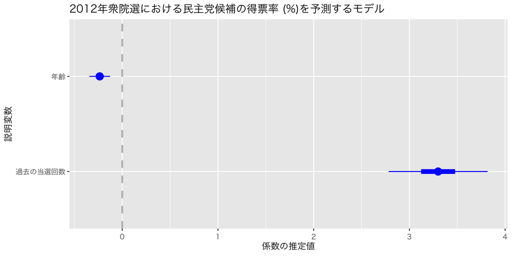

```r
coefs_q11 <- coefplot(
  model = fit_q11,    # 図示するモデルを指定
  intercept = FALSE,  # 切片を表示しない
  pointSize = 4,      # 点の大きさを4に
  ## 内側の線を50%信頼区間にする。既定値は1（「点推定値±1標準誤差」）
  innerCI = qt(df = summary(fit_q11)$df[2],
               p = 0.25, lower.tail = FALSE),
  lwdInner = 2.5,     # 内側の線の太さを2.5に
  ## 外側の線を95%信頼区間にする。既定値は2（「点推定値±2標準誤差」）
  outerCI = qt(df = summary(fit_q11)$df[2],
               p = 0.025, lower.tail = FALSE),
  lwdOuter = 0.5,     # 外側の線の太さを0.5に
  ## 説明変数を日本語で表示する
  newNames = list(previous = "過去の当選回数", age = "年齢"),
  xlab = "係数の推定値",
  ylab = "説明変数",
  title = "2012年衆院選における民主党候補の得票率 (%)を予測するモデル"
)
print(coefs_q11)
```

この図が推定結果をまとめている。縦軸にはモデルに含まれる説明変数が並んでいる。横軸は、係数の推定値の大きさを表している。図中の点は、各説明変数の係数の点推定値である。また、水平に引かれた線は、内側の太い線が50パーセント信頼区間、外側の細い線が95パーセント信頼区間である。いずれの変数についても、95パーセント信頼区間がゼロを跨いでいないので、5%の有意水準で、推定された効果は統計的に有意であることがわかる。この分析の標本サイズは264、自由度調整済み決定係数は0.38である。

### Q11-1-2

得票率 voteshare を応答変数、選挙費用 expm（100万円）を説明変数と想定して散布図を描き、回帰直線とその95%信頼区間を示す。

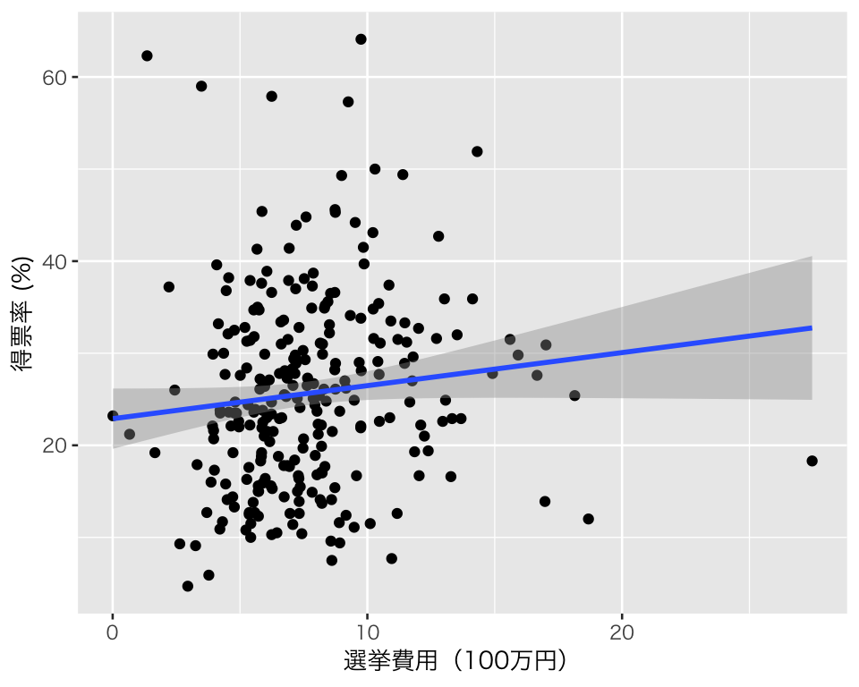

```r
scat_q11 <- ggplot(DPJ2012, aes(x = expm, y = voteshare)) +
  geom_point() +
  geom_smooth(method = "lm") +
  labs(x = "選挙費用（100万円）", y = "得票率 (%)")
print(scat_q11)
```